# Project: Ford GoBike Data Analysis

## Introduction

The Ford GoBike system is an integral part of the Bay Area’s transportation network. With more than 300 stations and 3,000 bikes on the ground across San Francisco, San Jose, Berkeley, Oakland and Emeryville, the system has generated over two million rides since launching in June 2017.[MTC (2022)](https://mtc.ca.gov/news/ford-gobike-ramps-ebikes#:~:text=About%20Ford%20GoBike,since%20launching%20in%20June%202017.)

[figure not shown]

This dataset contain information about trips taken using the Ford GoBike for a given period in the San Francisco Bay Area. Some useful features contained in this dataset include trip duration, start time, end time, start station_id, end station id, bike user id, etc. I will be exploring variables and relationships to answer some questions.

## Preliminary Wrangling

```python
# import all packages and set plots to be embedded inline
import numpy as np
import pandas as pd
import matplotlib.pyplot as plt
import seaborn as sb
import warnings
warnings.filterwarnings('ignore')

%matplotlib inline
```

In the next cells, the dataset needed will be imported programmatically and its properties will be described afterwards.

```python
import requests
url = 'https://video.udacity-data.com/topher/2020/October/5f91cf38_201902-fordgobike-tripdata/201902-fordgobike-tripdata.csv'
response = requests.get(url)

with open("fordgobike-tripdata.csv", mode='wb') as file:
    file.write(response.content)
```

```python
#Loading data using pandas.
df = pd.read_csv('fordgobike-tripdata.csv')
print(df.info())
df.head()
```

```
<class 'pandas.core.frame.DataFrame'>
RangeIndex: 183412 entries, 0 to 183411
Data columns (total 16 columns):
duration_sec               183412 non-null int64
start_time                 183412 non-null object
end_time                   183412 non-null object
start_station_id           183215 non-null float64
start_station_name         183215 non-null object
start_station_latitude     183412 non-null float64
start_station_longitude    183412 non-null float64
end_station_id             183215 non-null float64
end_station_name           183215 non-null object
end_station_latitude       183412 non-null float64
end_station_longitude      183412 non-null float64
bike_id                    183412 non-null int64
user_type                  183412 non-null object
member_birth_year          175147 non-null float64
member_gender              175147 non-null object
bike_share_for_all_trip    183412 non-null object
dtypes: float64(7), int64(2), object(7)
memory usage: 22.4+ MB
None
```

|  | duration_sec | start_time | end_time | start_station_id | start_station_name | start_station_latitude | start_station_longitude | end_station_id | end_station_name | end_station_latitude | end_station_longitude | bike_id | user_type | member_birth_year | member_gender | bike_share_for_all_trip |
| --- | --- | --- | --- | --- | --- | --- | --- | --- | --- | --- | --- | --- | --- | --- | --- | --- |
| 0 | 52185 | 2019-02-28 17:32:10.1450 | 2019-03-01 08:01:55.9750 | 21.0 | Montgomery St BART Station (Market St at 2nd St) | 37.789625 | -122.400811 | 13.0 | Commercial St at Montgomery St | 37.794231 | -122.402923 | 4902 | Customer | 1984.0 | Male | No |
| 1 | 42521 | 2019-02-28 18:53:21.7890 | 2019-03-01 06:42:03.0560 | 23.0 | The Embarcadero at Steuart St | 37.791464 | -122.391034 | 81.0 | Berry St at 4th St | 37.775880 | -122.393170 | 2535 | Customer | NaN | NaN | No |
| 2 | 61854 | 2019-02-28 12:13:13.2180 | 2019-03-01 05:24:08.1460 | 86.0 | Market St at Dolores St | 37.769305 | -122.426826 | 3.0 | Powell St BART Station (Market St at 4th St) | 37.786375 | -122.404904 | 5905 | Customer | 1972.0 | Male | No |
| 3 | 36490 | 2019-02-28 17:54:26.0100 | 2019-03-01 04:02:36.8420 | 375.0 | Grove St at Masonic Ave | 37.774836 | -122.446546 | 70.0 | Central Ave at Fell St | 37.773311 | -122.444293 | 6638 | Subscriber | 1989.0 | Other | No |
| 4 | 1585 | 2019-02-28 23:54:18.5490 | 2019-03-01 00:20:44.0740 | 7.0 | Frank H Ogawa Plaza | 37.804562 | -122.271738 | 222.0 | 10th Ave at E 15th St | 37.792714 | -122.248780 | 4898 | Subscriber | 1974.0 | Male | Yes |

```python
df.describe(include='all')
```

|  | duration_sec | start_time | end_time | start_station_id | start_station_name | start_station_latitude | start_station_longitude | end_station_id | end_station_name | end_station_latitude | end_station_longitude | bike_id | user_type | member_birth_year | member_gender | bike_share_for_all_trip |
| --- | --- | --- | --- | --- | --- | --- | --- | --- | --- | --- | --- | --- | --- | --- | --- | --- |
| count | 183412.000000 | 183412 | 183412 | 183215.000000 | 183215 | 183412.000000 | 183412.000000 | 183215.000000 | 183215 | 183412.000000 | 183412.000000 | 183412.000000 | 183412 | 175147.000000 | 175147 | 183412 |
| unique | NaN | 183401 | 183397 | NaN | 329 | NaN | NaN | NaN | 329 | NaN | NaN | NaN | 2 | NaN | 3 | 2 |
| top | NaN | 2019-02-15 08:43:18.4220 | 2019-02-14 08:20:06.2300 | NaN | Market St at 10th St | NaN | NaN | NaN | San Francisco Caltrain Station 2 (Townsend St... | NaN | NaN | NaN | Subscriber | NaN | Male | No |
| freq | NaN | 2 | 2 | NaN | 3904 | NaN | NaN | NaN | 4857 | NaN | NaN | NaN | 163544 | NaN | 130651 | 166053 |
| mean | 726.078435 | NaN | NaN | 138.590427 | NaN | 37.771223 | -122.352664 | 136.249123 | NaN | 37.771427 | -122.352250 | 4472.906375 | NaN | 1984.806437 | NaN | NaN |
| std | 1794.389780 | NaN | NaN | 111.778864 | NaN | 0.099581 | 0.117097 | 111.515131 | NaN | 0.099490 | 0.116673 | 1664.383394 | NaN | 10.116689 | NaN | NaN |
| min | 61.000000 | NaN | NaN | 3.000000 | NaN | 37.317298 | -122.453704 | 3.000000 | NaN | 37.317298 | -122.453704 | 11.000000 | NaN | 1878.000000 | NaN | NaN |
| 25% | 325.000000 | NaN | NaN | 47.000000 | NaN | 37.770083 | -122.412408 | 44.000000 | NaN | 37.770407 | -122.411726 | 3777.000000 | NaN | 1980.000000 | NaN | NaN |
| 50% | 514.000000 | NaN | NaN | 104.000000 | NaN | 37.780760 | -122.398285 | 100.000000 | NaN | 37.781010 | -122.398279 | 4958.000000 | NaN | 1987.000000 | NaN | NaN |
| 75% | 796.000000 | NaN | NaN | 239.000000 | NaN | 37.797280 | -122.286533 | 235.000000 | NaN | 37.797320 | -122.288045 | 5502.000000 | NaN | 1992.000000 | NaN | NaN |
| max | 85444.000000 | NaN | NaN | 398.000000 | NaN | 37.880222 | -121.874119 | 398.000000 | NaN | 37.880222 | -121.874119 | 6645.000000 | NaN | 2001.000000 | NaN | NaN |

### What is the structure of your dataset?

> The dataset contains 183412 fordgobike journeys with 16 specifications (duration sec, start time, end time, start station id, start station name, start station latitude, start station longitude, bike id, user type, member birth year, member gender, bike share for all trip). Nine of the sixteen specifications are numerical, two are datetime, four are object type, and one is boolean type.

### What is/are the main feature(s) of interest in your dataset?

> I am particularly interested in determining how trip duration is affected by other features in the dataset.

### What features in the dataset do you think will help support your investigation into your feature(s) of interest?

> I anticipate that trip time will be significantly dependent on the distance between start and end stations, and the age of the rider; I also believe that user type and gender should have an impact on journey time.

## Data Assessment and Cleaning

### Issue: Missing values

The following features have missing values.

- start_station_id, end_station_id, end_station_name, member_birth_year and member_gender

```python
df.dropna(inplace=True)
df.info()
```

```
<class 'pandas.core.frame.DataFrame'>
Int64Index: 174952 entries, 0 to 183411
Data columns (total 16 columns):
duration_sec               174952 non-null int64
start_time                 174952 non-null object
end_time                   174952 non-null object
start_station_id           174952 non-null float64
start_station_name         174952 non-null object
start_station_latitude     174952 non-null float64
start_station_longitude    174952 non-null float64
end_station_id             174952 non-null float64
end_station_name           174952 non-null object
end_station_latitude       174952 non-null float64
end_station_longitude      174952 non-null float64
bike_id                    174952 non-null int64
user_type                  174952 non-null object
member_birth_year          174952 non-null float64
member_gender              174952 non-null object
bike_share_for_all_trip    174952 non-null object
dtypes: float64(7), int64(2), object(7)
memory usage: 22.7+ MB
```

### Issue: Datatypes

The datatypes for the following needs to be corrected.

- start_time, end_time
- start_station_id, end_station_id, bike_id

```python
# Define: Correct the datatypes
# Code
cols = ['start_station_id', 'end_station_id', 'bike_id']
for i in cols:
    df[i] = df[i].astype('str')
df['member_birth_year'] = df['member_birth_year'].astype('int')
#Test
print(df.info())
```

```
<class 'pandas.core.frame.DataFrame'>
Int64Index: 174952 entries, 0 to 183411
Data columns (total 16 columns):
duration_sec               174952 non-null int64
start_time                 174952 non-null object
end_time                   174952 non-null object
start_station_id           174952 non-null object
start_station_name         174952 non-null object
start_station_latitude     174952 non-null float64
start_station_longitude    174952 non-null float64
end_station_id             174952 non-null object
end_station_name           174952 non-null object
end_station_latitude       174952 non-null float64
end_station_longitude      174952 non-null float64
bike_id                    174952 non-null object
user_type                  174952 non-null object
member_birth_year          174952 non-null int64
member_gender              174952 non-null object
bike_share_for_all_trip    174952 non-null object
dtypes: float64(4), int64(2), object(10)
memory usage: 22.7+ MB
None
```

```python
# Define: correct the datatype from string to datetime
# Code:
df['start_time']=pd.to_datetime(df['start_time'])
df['end_time']=pd.to_datetime(df['end_time'])
# Test
df.info()
```

```
<class 'pandas.core.frame.DataFrame'>
Int64Index: 174952 entries, 0 to 183411
Data columns (total 16 columns):
duration_sec               174952 non-null int64
start_time                 174952 non-null datetime64[ns]
end_time                   174952 non-null datetime64[ns]
start_station_id           174952 non-null object
start_station_name         174952 non-null object
start_station_latitude     174952 non-null float64
start_station_longitude    174952 non-null float64
end_station_id             174952 non-null object
end_station_name           174952 non-null object
end_station_latitude       174952 non-null float64
end_station_longitude      174952 non-null float64
bike_id                    174952 non-null object
user_type                  174952 non-null object
member_birth_year          174952 non-null int64
member_gender              174952 non-null object
bike_share_for_all_trip    174952 non-null object
dtypes: datetime64[ns](2), float64(4), int64(2), object(8)
memory usage: 22.7+ MB
```

### Issue: Unrealistic data range

From the `df.describe(include='all')` output, we saw that the member_birth_year has a minimum of 1878. This implies that such members are overaged and don't have the strength and capacity to ride a bike. Since we have enough records to work with, such entries will be dropped, and the minimum birth year will be set to 1940.

```python
# Define: Drop unrealistic entries
# Code
df_c = df[df['member_birth_year']>1940]
# Test
df_c['member_birth_year'].describe()
```

```
count    174749.000000
mean       1984.877665
std           9.871342
min        1941.000000
25%        1980.000000
50%        1987.000000
75%        1992.000000
max        2001.000000
Name: member_birth_year, dtype: float64
```

### Issue: Removal of outliers

```python
# Defining a function for identifying upper and lower limits
def outlier(i):
    '''returns the upper and lower limits of a quantitative variable'''
    q3=i.quantile(.75)
    q2=i.quantile(.25)
    IQR=q3-q2
    u=i.quantile(.75)+1.5*IQR
    l=i.quantile(.25)-1.5*IQR
    output = print(f"The upper limit is: {u}\nThe lower limit is: {l}")
    return output
outlier(df_c['duration_sec'])
```

```
The upper limit is: 1488.0
The lower limit is: -376.0
```

```python
#deleting records outside the upper limit
df_c = df_c[df_c['duration_sec']<=1488]
```

### Feature Engineering

There is need to create new features or data item to gain reasonable insight form this dataset.For example, we would like to know the age group with the longest minutes spent. This implies that a new data item `duration_min` needs to be created.

```python
# express the duration_sec in minutes
df_c['duration_min'] = (df_c['duration_sec']/60).round(2)
df_c['duration_min'].describe()
```

```
count    165428.000000
mean          9.173044
std           5.070174
min           1.020000
25%           5.230000
50%           8.130000
75%          12.180000
max          24.800000
Name: duration_min, dtype: float64
```

```python
# extracting age from birth year
df_c['member_age']=np.subtract(2019,df_c['member_birth_year'])
df_c['member_age'].describe()
```

```
count    165428.000000
mean         34.089616
std           9.789480
min          18.000000
25%          27.000000
50%          32.000000
75%          39.000000
max          78.000000
Name: member_age, dtype: float64
```

```python
#Creating a new variable Distance_in_KM
from math import sin, cos, asin, sqrt
def get_distance(row, R = 6371): #to be expressed in kilometer
    dlon = row[1]['end_station_longitude'] - row[1]['start_station_longitude']
    dlat = row[1]['end_station_latitude'] - row[1]['start_station_latitude']

    a = ((sin(dlat/2))**2 + cos(row[1]['start_station_latitude']) * cos(row[1]['end_station_latitude']) * (sin(dlon/2))**2)
    c = 2 * asin(sqrt(a))
    return R * c

df_c['distance_in_km'] = [get_distance(row) for row in df_c.iterrows()]
df_c.info()
```

```
<class 'pandas.core.frame.DataFrame'>
Int64Index: 165428 entries, 6 to 183411
Data columns (total 19 columns):
duration_sec               165428 non-null int64
start_time                 165428 non-null datetime64[ns]
end_time                   165428 non-null datetime64[ns]
start_station_id           165428 non-null object
start_station_name         165428 non-null object
start_station_latitude     165428 non-null float64
start_station_longitude    165428 non-null float64
end_station_id             165428 non-null object
end_station_name           165428 non-null object
end_station_latitude       165428 non-null float64
end_station_longitude      165428 non-null float64
bike_id                    165428 non-null object
user_type                  165428 non-null object
member_birth_year          165428 non-null int64
member_gender              165428 non-null object
bike_share_for_all_trip    165428 non-null object
duration_min               165428 non-null float64
member_age                 165428 non-null int64
distance_in_km             165428 non-null float64
dtypes: datetime64[ns](2), float64(6), int64(3), object(8)
memory usage: 25.2+ MB
```

```python
#Creating a new data item age group
df_c['age_group']=pd.cut(df_c['member_birth_year'],
                         bins=[1941,1945,1964,1980,1996,2001],
                        labels=['Post War','Boomers','Gen X','Millenials','Gen Z'])
df_c['age_group'].head()
```

```
6     Millenials
9     Millenials
10    Millenials
11    Millenials
12    Millenials
Name: age_group, dtype: category
Categories (5, object): [Post War < Boomers < Gen X < Millenials < Gen Z]
```

```python
df_c.columns
```

```
Index(['duration_sec', 'start_time', 'end_time', 'start_station_id',
       'start_station_name', 'start_station_latitude',
       'start_station_longitude', 'end_station_id', 'end_station_name',
       'end_station_latitude', 'end_station_longitude', 'bike_id', 'user_type',
       'member_birth_year', 'member_gender', 'bike_share_for_all_trip',
       'duration_min', 'member_age', 'distance_in_km', 'age_group'],
      dtype='object')
```

```python
#deleting unnecessary features
d=['duration_sec', 'start_time', 'end_time', 'start_station_id',
       'start_station_name', 'start_station_latitude',
       'start_station_longitude', 'end_station_id', 'end_station_name',
       'end_station_latitude', 'end_station_longitude', 'bike_id',
       'member_birth_year', 'bike_share_for_all_trip']
for i in d:
    del df_c[i]
```

```python
df_c.describe(include='all')
```

|  | user_type | member_gender | duration_min | member_age | distance_in_km | age_group |
| --- | --- | --- | --- | --- | --- | --- |
| count | 165428 | 165428 | 165428.000000 | 165428.000000 | 165428.000000 | 165422 |
| unique | 2 | 3 | NaN | NaN | NaN | 5 |
| top | Subscriber | Male | NaN | NaN | NaN | Millenials |
| freq | 151758 | 123986 | NaN | NaN | NaN | 112709 |
| mean | NaN | NaN | 9.173044 | 34.089616 | 105.052212 | NaN |
| std | NaN | NaN | 5.070174 | 9.789480 | 63.482763 | NaN |
| min | NaN | NaN | 1.020000 | 18.000000 | 0.000000 | NaN |
| 25% | NaN | NaN | 5.230000 | 27.000000 | 58.215511 | NaN |
| 50% | NaN | NaN | 8.130000 | 32.000000 | 89.583263 | NaN |
| 75% | NaN | NaN | 12.180000 | 39.000000 | 138.621700 | NaN |
| max | NaN | NaN | 24.800000 | 78.000000 | 467.535878 | NaN |

After data wrangling, we are left with `6` columns and `165,428` rows. This will enable us to focus on what is relevant.

*In the next section, we will be focusing on univariate exploration of data.*

## Univariate Exploration

The major variable of interest in this analysis is the `duration_min`, which is the defined as the time spent using the bike - from the start station to the end station. Since this variable is a numeric variable, It is very helpful to understand the distribution of this variable and some of its properties using a histogram.

```
count    165428.000000
mean          9.173044
std           5.070174
min           1.020000
25%           5.230000
50%           8.130000
75%          12.180000
max          24.800000
Name: duration_min, dtype: float64
```

```
Text(0.5,0,'Duration (in Minutes)')
```

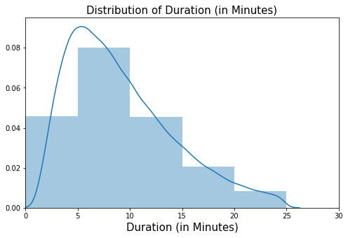

```python
print(df_c['duration_min'].describe())
plt.figure(figsize=[8,5])
bins=np.arange(0,df_c['duration_min'].max()+5,5)
sb.distplot(df_c['duration_min'],bins=bins)
plt.xlim((0,30))
plt.title('Distribution of Duration (in Minutes)',fontsize=15)
plt.xlabel('Duration (in Minutes)', fontsize=15)
```

From the plot above and the descriptive statistics provided, this variable is positively skewed or right-skewed, that is, the mean `9.173044` is greater than the median `8.13` of this variable. Furthermore, the descriptive statistics tell us that 50% of the data falls between this interval: `5.23-12.18`.

In the following cells, we would like to examine the distribution of the other numeric variables - `distance_in_km` and `member_age` - in the dataset using the same technique.

```
count    165428.000000
mean        105.052212
std          63.482763
min           0.000000
25%          58.215511
50%          89.583263
75%         138.621700
max         467.535878
Name: distance_in_km, dtype: float64
```

```
Text(0.5,0,'Distance (in Kilometer)')
```

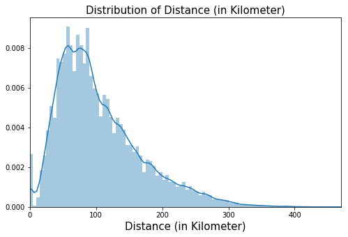

```python
print(df_c['distance_in_km'].describe())
plt.figure(figsize=[8,5])
bins=np.arange(0,df_c['distance_in_km'].max()+5,5)
sb.distplot(df_c['distance_in_km'],bins=bins)
plt.xlim((0,470))
plt.title('Distribution of Distance (in Kilometer)',fontsize=15)
plt.xlabel('Distance (in Kilometer)', fontsize=15)
```

From the plot above and the descriptive statistics provided, this variable - `distance_in_km` - is positively skewed or right-skewed, that is, the mean `105.052212` is greater than the median `89.583263` of this variable. Furthermore, the descriptive statistics tell us that 50% of the data falls between this interval: `58.215511`-`138.621700`.

Since the first two have shown similar behaviour, it is not wrong to expect the same for the third numeric variable in this analysis.

```
count    165428.000000
mean         34.089616
std           9.789480
min          18.000000
25%          27.000000
50%          32.000000
75%          39.000000
max          78.000000
Name: member_age, dtype: float64
```

```
Text(0.5,0,'Memeber age')
```

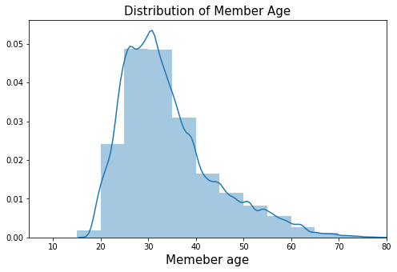

```python
print(df_c['member_age'].describe())
plt.figure(figsize=[8,5])
bins=np.arange(0,df_c['member_age'].max()+5,5)
sb.distplot(df_c['member_age'],bins=bins)
plt.xlim((5,80))
plt.title('Distribution of Member Age',fontsize=15)
plt.xlabel('Memeber age', fontsize=15)
```

Just as we had expected! The plot above shows that this variable - `member_age` - is positively skewed or right-skewed, with a mean of `34.089616` and a median of `32.0`. Furthermore, the descriptive statistics tell us that 50% of the data falls between this interval: `27.0`-`39.0`. How does this similarity in distribution affect our conclusions?

Having explored the distribution of each of the numeric variables in the dataset, we proceed with exploring other variables considered *important* in this exploratory analysis. We will start by exploring the variable `member_gender` using a pie chart.

```
(-1.1017885175188391,
 1.1203459806720952,
 -1.120301170697217,
 1.1018333274937173)
```

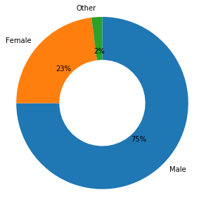

```python
plt.figure(figsize=[8,5])
sorted_counts = df_c['member_gender'].value_counts()
plt.pie(sorted_counts, labels = sorted_counts.index, startangle = 90,
        counterclock = False, wedgeprops = {'width' : 0.5},autopct='%.0f%%')
plt.axis('square')
```

The pie chart above suggests that **`75%`** of those who used Ford GoBike in the month of February are `Male` and the remaining **`25%`** is shared between `Female` and `Other`, with the latter having the smallest share. This result is not far from what's expected in the real world. In the real worl, the avarage `Male` tend to ride a bicycle compared to the other gender categories.

Next, we would like to explore the distribution of users. Let's understand those who use the Ford GoBike. Are there more subscribers than customers? Or is the reverse the case? Let's find out using a bar chart.

```
Text(0,0.5,'Count')
```

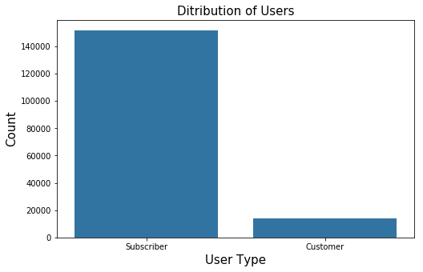

```python
base_color = sb.color_palette()[0]
plt.figure(figsize=[8,5])
sb.countplot(x='user_type',data=df_c,color=base_color)
plt.title('Ditribution of Users',fontsize=15)
plt.xlabel('User Type',fontsize=15)
plt.ylabel('Count', fontsize=15)
```

The chart shows a great difference between the category of users. The **`Subscriber`** category has obviously has the upper hand as revealed in the plot above. This reveals that the services rendered by the Ford GoBike is worth paying for. On the other hand, it seems the few other users don't have incentive to join the subscribers. The reason behind that is outside the scope of this study; the best we can do is to make assumptions.

The next variable of interest here is the **`Age group`**. In the data wrangling stage, a new data item/feature was added to the dataset. This feature breaks down the birth year of members into different categories - `Post War` (1941-1945), `Boomers` (1946-1964), `Gen X` (1965-1980), `Millenials` (1981-1996) and `Gen Z` (1997-2001). The next visual shows the distribution/count of this variable.

```
Text(0,0.5,'Count')
```

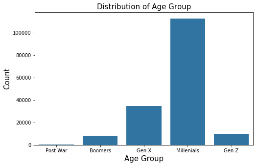

```python
plt.figure(figsize=[8,5])
sb.countplot(x='age_group',data=df_c,color=base_color)
plt.title('Distribution of Age Group',fontsize=15)
plt.xlabel('Age Group',fontsize=15)
plt.ylabel('Count', fontsize=15)
```

*In the next section, I will be using visuals to explore the relationship between two variables.*

### Discuss the distribution(s) of your variable(s) of interest. Were there any unusual points? Did you need to perform any transformations?

> As mentioned earlier, the variable of interest in this analysis is `duration_min`. This variable, together with other numeric variables included in this analysis, is positively skewed. There was no need for further transformation.

## Bivariate Exploration

In this section, we will be exploring relationships between pairs of variables in the data. Starting with the variable of interest - `duration_min`, one would like to explore its relationship with other numeric variables like `distance_in_km` and `member_age` to see if a possitive or negative relationship exists. First, what is the relationship between `duration_min` and `distance_in_km`? The scatter plot will be used to answer this question.

```
Text(0.5,1,'Duration vs Distance')
```

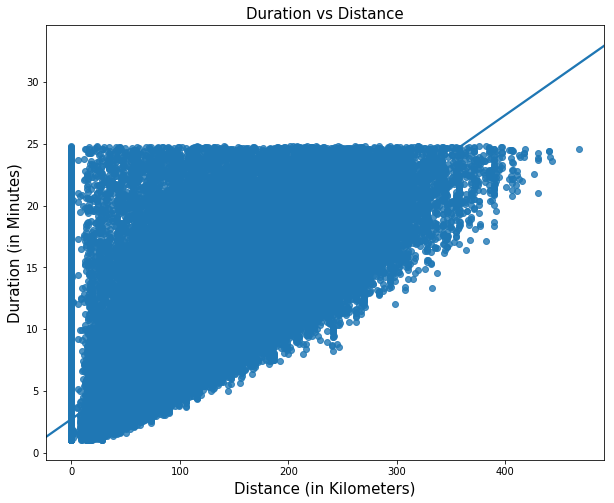

```python
plt.figure(figsize=[10,8])
sb.regplot(x='distance_in_km',y='duration_min',data=df_c)
plt.xlabel('Distance (in Kilometers)', fontsize=15)
plt.ylabel('Duration (in Minutes)', fontsize=15)
plt.title('Duration vs Distance',fontsize=15)
```

Although this plot already suggests a positive relationship, it doesn't give us an interesting representation. A sample of 200 observations should provide us with a much better view.

```
Text(0.5,1,'Duration vs Distance - n=200')
```

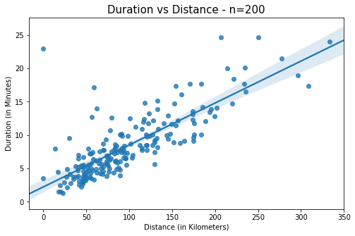

```python
k=df_c.sample(200)
plt.figure(figsize=[8,5])
sb.regplot(x='distance_in_km',y='duration_min',data=k)
plt.xlabel('Distance (in Kilometers)')
plt.ylabel('Duration (in Minutes)')
plt.title('Duration vs Distance - n=200', fontsize=15)
```

With a sample of 200 observations, there is a clear positive reationship between `distance_in_km` and `duration_min`. That is, as the distance covered increases, the duration spent (in minutes) inreases.

We proceed to exploring the relationship between `duration_min` and `member_age`. Could it be that a strong positive relationship exists between these variable?

```
Text(0.5,1,'Duration vs Member Age')
```

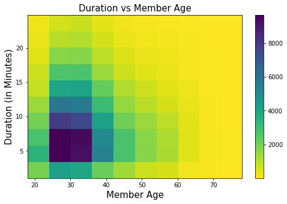

```python
plt.figure(figsize=[8,5])
plt.hist2d(x='member_age',y='duration_min',data=df_c,
           cmin=0.5, cmap = 'viridis_r')
plt.colorbar()
plt.xlabel('Member Age',fontsize=15)
plt.ylabel('Duration (in Minutes)',fontsize=15)
plt.title('Duration vs Member Age',fontsize=15)
```

```
Text(0.5,1,'Member Age vs Distance Covered')
```

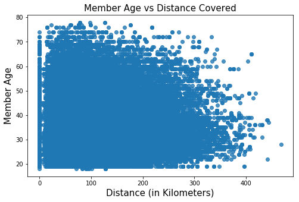

```python
plt.figure(figsize=[8,5])
sb.regplot(x='distance_in_km',y='member_age',data=df_c,fit_reg=False)
plt.xlabel('Distance (in Kilometers)',fontsize=15)
plt.ylabel('Member Age',fontsize=15)
plt.title('Member Age vs Distance Covered',fontsize=15)
```

As expected, a positive relationship exists between the variables plotted above. However, this positive realtionship is a very weak one as seen in the scatter plot above between the distance covered and the age of members. Also, this plot is not clear enough to reveal this relationship. Let's see the outcome with 200 randomly sampled observations below.

```
Text(0.5,1,'Member Age vs Distance Covered')
```

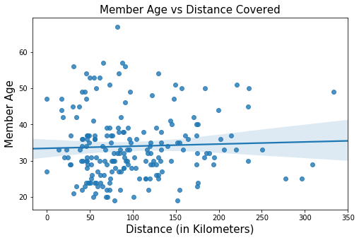

```python
plt.figure(figsize=[8,5])
sb.regplot(x='distance_in_km',y='member_age',data=k,fit_reg=True)
plt.xlabel('Distance (in Kilometers)',fontsize=15)
plt.ylabel('Member Age',fontsize=15)
plt.title('Member Age vs Distance Covered',fontsize=15)
```

Having explored the relationship between numeric variables, it's time to explore relationhips between quantitative and qualitative varibles. At this point, I will be exploring the relationship between member age and gender.

```
Text(0.5,1,'Gender by Age')
```

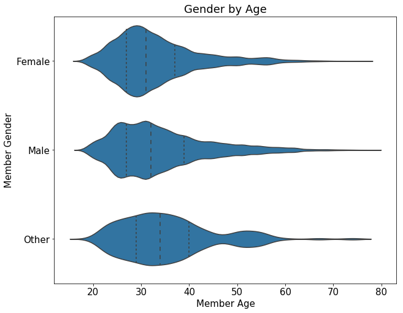

```python
plt.figure(figsize=[10,8])
sb.violinplot(data=df_c, x='member_age',y='member_gender',
              color=base_color,inner='quartile')
plt.xticks(fontsize=15)
plt.yticks(fontsize=15)
plt.ylabel('Member Gender', fontsize=15)
plt.xlabel('Member Age', fontsize=15)
plt.title('Gender by Age', fontsize=18)
```

The visual above tells us that the average age of the female category is the lowest compared to the other categories. With an average age of `35.601147`, the `Other` category has the highest avegrage age. Why? This is because it has the smallest number of entries/observations among the three categories. This also explains why it has the larger value in terms of upper and lower quartiles.

In the next visual, we will explore the relationship between `Age group` an `duration` using box plot.

```
Text(0.5,1,'Duration by Age Group')
```

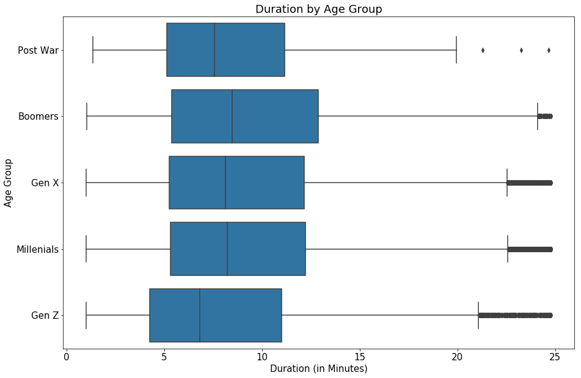

```python
plt.figure(figsize=[15,10])
sb.boxplot(data=df_c, y='age_group',x='duration_min', color=base_color)
plt.ylabel('Age Group', fontsize=15)
plt.xticks(fontsize=15)
plt.yticks(fontsize=15)
plt.xlabel('Duration (in Minutes)', fontsize=15)
plt.title('Duration by Age Group', fontsize=18)
```

From the visual above, it is clear that `Boomers` has the highest median duration vlaue which is approximately `8.5 mins` compared to the rest. With a median value which is approximately `6.8 mins`, `Gen Z` records the lowest trip time. The median duration and the interquartile range seems to be equal for both `Gen X` and `Millenials`. A closer investigation, using summary statistics, showed that `Gen X` and `Millenials` has a median value of `8.13` and `8.23` respectively.

### Talk about some of the relationships you observed in this part of the investigation. How did the feature(s) of interest vary with other features in the dataset?

> I observed that a strong positive relationship exist between minutes per trip and the distance covered. This was in alignment with my apriori expectation. Although a positive relationship exists between the member age and the minutes per trip, the correlation was a weak one, which was unexpected.

### Did you observe any interesting relationships between the other features (not the main feature(s) of interest)?

> Exploring the relationship between geneder and age ahowed that the average age of the female category is the lowest compared to the other categories. With an average age of approximately 36, the Other category has the highest avegrage age. This was attributed to the fact that it has the smallest number of entries/observations among the three categories. This also explains why it has the larger value in terms of upper and lower quartiles.

## Multivariate Exploration

```
Text(0.5,1,'Relationship Between Quantitative Variables')
```

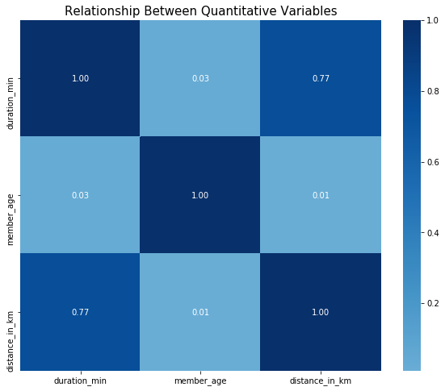

```python
# Plotting a correlation matrix using a Heatmap.
plt.figure(figsize=[10,8])
l=df_c[['duration_min','member_age','distance_in_km']]
sb.heatmap(l.corr(),annot=True,fmt=".2f",
           cmap='Blues', center=0)
plt.title('Relationship Between Quantitative Variables', fontsize=15)
```

The above plot clearly captures the linear relationship between all relevant quantitative variables used in this analysis. It clearly depicts that there is a strong correlation between duration and distance, and a very weak, positive linear relationship exists between every other pair.

Having explored the existing relationship between `distance_in_km` and `duration_min`, it is useful to add another variable to further understand and gain more insights.

```
Text(0.5,1,'Duration vs Distance, by Age')
```

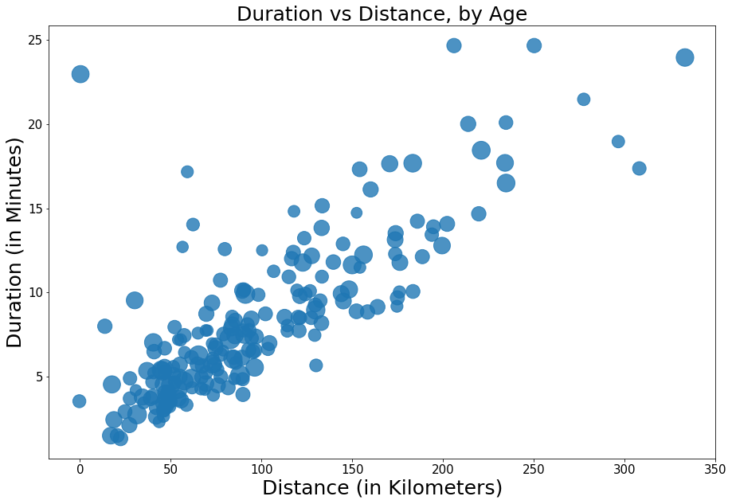

```python
plt.figure(figsize=[15,10])
sb.regplot(x='distance_in_km',y='duration_min',data=k, fit_reg=False,
           x_jitter=0.5, scatter_kws={'s':k['member_age']*10})
plt.xticks(fontsize=15)
plt.yticks(fontsize=15)
plt.ylabel('Duration (in Minutes)',fontsize=25)
plt.xlabel('Distance (in Kilometers)',fontsize=25)
plt.title('Duration vs Distance, by Age',fontsize=25)
```

`member_age` has been encoded into the plot above using bubble size. The plot above shows that most individuals who used Ford GoBike in February 2019 are young adults as represented by the high occurrence of small-sized bubbles.

### Talk about some of the relationships you observed in this part of the investigation. Were there features that strengthened each other in terms of looking at your feature(s) of interest?

> In the multivariate section, a correlation matrix was used to display the linear relationship between all quantitative variables used in this analysis. The plot showed that there is a strong correlation between duration and distance, and a very weak, positive linear relationship exists between every other pair.

> Having explored the relationship between distance_in_km and duration*min in the bivariate section, we decided to explore the interaction member* age would have with the other two variables.

## Conclusions

> This exploration has exposed us to the exciting properties of the Ford GoBike Trip data. We saw that most Males used bikes more than other gender categories in the exploration, and that over 85% of bike users are subscribers. The quantitative variables are positively skewed leaving us with no incentive to use advance statistical techniques like multiple linear regression, even when trip time and distance covered has high correlation.